# RBB Final Project

Debra Okeh

2023-08-08

# 1 Analysis of the Knowledge of AIDS in Nigeria using DHS Women data

## 1.1 Introduction

The dataset contains data on the female gender across various health issues and concerns. Given that each row represents a respondent with a specific case ID which is recorded, the total number of cases recorded is 41821. The data which was used in the report was extracted from the Demographic and Health Survey (DHS) file made available for this final project and contains Nigerian data only. For this report, the topic of interest from the DHS data is `AIDS and Condom Use`. However, the major focus of the report is on the knowledge based variable of the Acquired Immune Deficiency Syndrome. AIDS is not contracted as AIDS. It is the advanced stage of the `Human Immunodeficiency Virus` (HIV) infection. Untreated HIV after many years progresses to AIDS. This report analyzes how variables such as `marital status`, `age`, `occupation` and `educational level` affects the respondents knowledge of HIV/AIDS, its spread and possible prevention (transfer risk reduction) methods. The analysis is presented in sections with relevant charts and numerical statistics as well.

### 1.1.1 Age Distribution of respondents

The age range recorded for this study is from 15 - 49 years. Out of the 41821 females that participated in the survey, `8423` i.e. `20.14%` were in the age bracket of 15 - 19 years and are the most populous of all the age groups. The age group of 45 - 49 were the smallest with `3891` i.e. `9.30%`. The age group with the second highest number was 25 - 29 having `7203` i.e. `17.22%`. The chart in `Figure 1` shows the histogram of age distribution of the respondents.

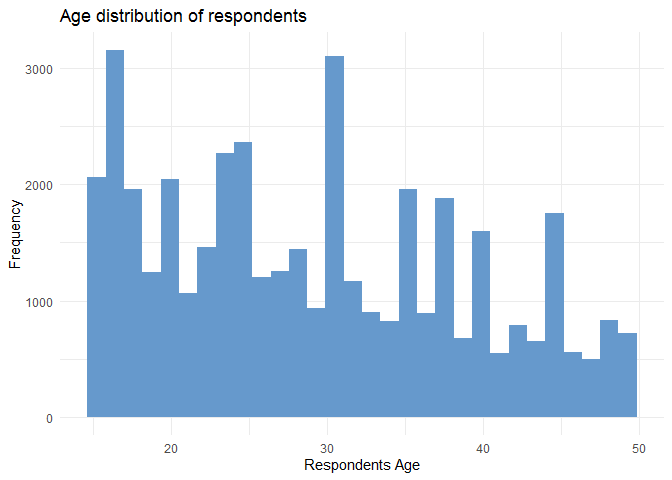

Figure 1

The chart clearly corresponds with the figures given earlier. The bars are higher around the 15 - 19 and 25 - 29 years age ranges and is much lower as one moves to the right towards the ages of 45 - 49 years. The histogram also indicates that a high proportion of the respondents are youths between the ages of 15 - 35.

## 1.2 AIDS Awareness

The awareness level of AIDS of the respondents were tested by asking them if they had previously heard of the Acquired Immune Deficiency Syndrome (AIDS). Out of the 41821 respondents, 39257 i.e. 93.7% were aware that AIDS existed and had heard about it while 2564 i.e. 6.13% had never heard about AIDS before. This shows that the awareness level for AIDS is high given the number of people who have heard of it before. This awareness variable is further broken into various categories of repondents to see how other variables in the study influence it.

### 1.2.1 Awareness by Age group

The awareness level of different age groups was checked to see which age group was much aware and which was least aware according to the number i each age group that indicated aware or not. The chart in `Figure 2` shows the results of this analysis.

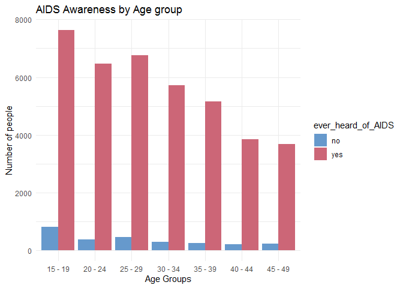

Figure 2

### 1.2.2 Awareness by Level of Education

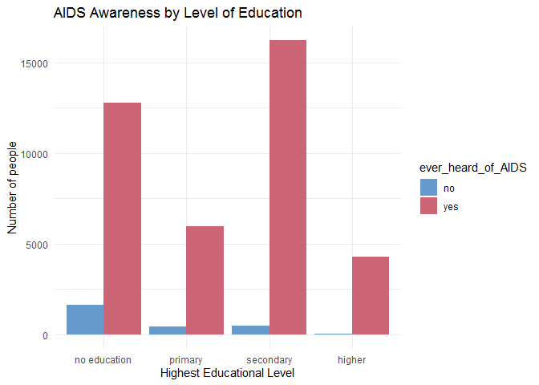

Figure 3

### 1.2.3 Awareness by Marital Status

Marital status was considered as a variable with which to check the awareness of the respondents to AIDS. Over `50%` of the respondents were married and `25.5%` have never been in a union. The smallest group was divorce having `1.3%`. The chart in `Figure 4` shows the results of this analysis.

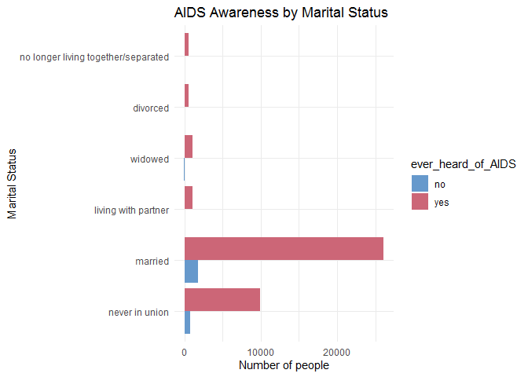

Figure 4

The chart reveals that according to marital status, many of the respondents who have heard about AIDS were married and the second group was those who had never been in a union. The group with the least number of hearing about AIDS were the divorced respondents.

### 1.2.4 Awareness by Occupation

Among the respondents were people who had diverse occupations. Occupations ranging from sales with over `14000` respondents, agriculture having `7325` respondents, services with `2708` to household and domestic which had no respondents. None of the respondents indicated that they were not working. `Figure 5` shows which sectors had the highest responses to being aware of AIDS.

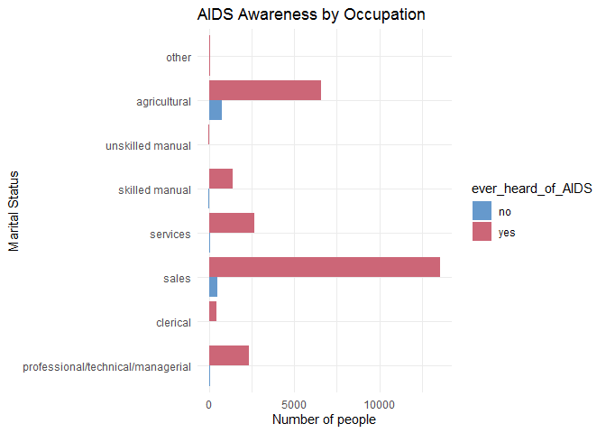

Figure 5

It can be seen from the chart that those who were in the sales sector appeared to have heard it more than other sectors, followed by those in the agricultural sector. Unskilled manual workers had heard of it the least.

## 1.3 Spread of HIV

The respondents were asked questions on how HIV spread. These questions were kind of trick questions in order to understand what they realy knew about AIDS. They were asked if HIV could be spread by mosquito bites and whether one could be infected with HIV by eating with someone who was infected already. Their responses were analysed along the lines of age and educational level are presented here.

### 1.3.1 Spread of HIV through mosquito bites

Mosquito bites are unable to facilitate the transfer of AIDS from a carrier to a healthy person. However, this question turned out some interesting results when analysed.

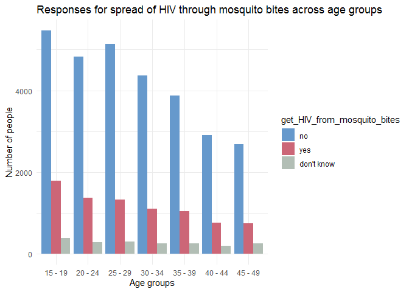

Figure 6

In the chart in `Figure 6` it can be seen that the majority agree that HIV cannot be transfered through mosquito bites by responding no to the quesion especially the 15 - 19 age group. It is also interesting to note that `20%` of the respondents stated that mosquito bites can transfer HIV and the remaining respondents replied that they do not know. This points out that inasmuch as the respondents reveal that they have heard of HIV, they do not fully understand its operations. When the analysis was performed by educational level, the plot in `Figure 7` shows the results.

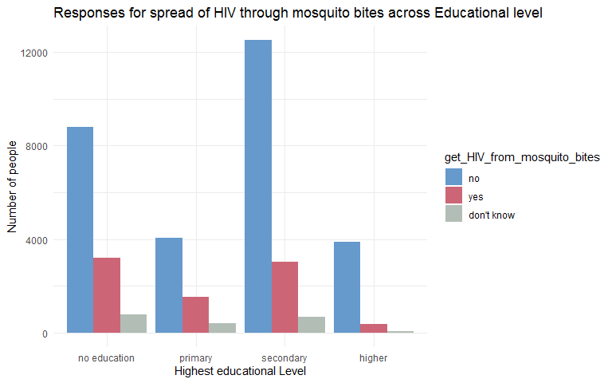

Figure 7

The chart reveals that those who went to secondary school do not agree that mosquito bites transmit HIV. For this group, people with no formal education had the most responses agreeing to the spread of HIV through mosoquito bites.

### 1.3.2 Spread of HIV through sharing of food with carrier

The respondents also answered this question with responses of `yes`, `no` and I `don't know` based on their understanding of AIDS. `Figure 8` shows their responses according to their age groups.

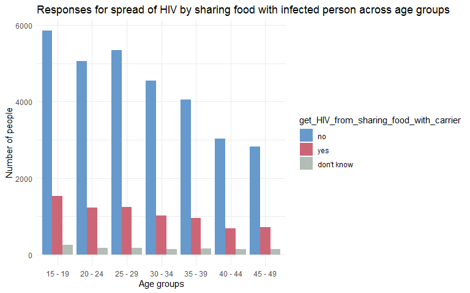

Figure 8

Over `50%` of people from all the age groups responded that sharing food with an infected person is not enough to transmit HIV to that person. Some persons still believe that sharing food with people infected people can lead to contracting the disease and that is not true. The remaining people responded that they did not know.

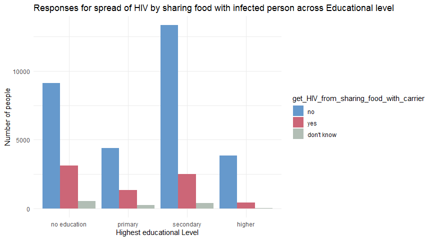

Figure 9

The chart in `Figure 9` above shows that those who attained up to secondary school do not agree that sharing food with infected can lead to transmission. Also, those with no formal education appeared to agree more that sharing food with a carrier can lead to transmission.

## 1.4 Reducing the risk of HIV spread

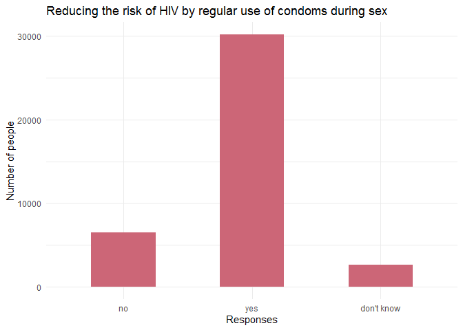

Figure 10

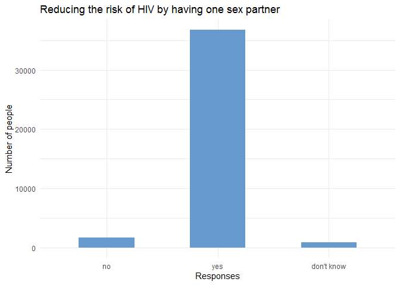

Figure 11

`Figure 11` shows the responses for the method of having one sex partner. A total number of 36732 supported the approach with only a few i.e. 1701 negating it and the rest not being sure about it.

## 1.5 Conclusion

HIV over time has become a major public health concern. A lot of people are carriers of the infection and most might not know. A lot of effort, time and resources is constantly being put together for awareness and senditization campaigns. This report has made it clear that among the women in Nigeria that particpated in the survey, over 90% of them have heard of AIDS and that in itself shows that awareness campaigns are paying off. However, there is need for more effort to be put in in educating them on the various ways through which HIV can be contracted and transmitted among people as well as the major prevention or risk reduction strategies . Also, there is a need to also encourage them to go for HIV tests and if positive begin to take their drugs on time as untreated HIV infections over time develops into AIDS.